# Lesson4

Sung Won Kang

2016년 11월 19일

#### A. 모수와 통계량

1. 모수: 모집단의 특성을 나타내는 값
   - 모집단의 분포를 정의
2. 표본: 모집단의 일부를 추출한 값
   - 표본 추출: 임의 추출(random sample), 복원추출을 가정
   - 임의 추출: 개별 sample의 독립성(independency)을 확보하는 과정
   - 비복원추출은 개별 sample 의 확률분포가 달라지는 문제가 발생(교과서 p. 156.(4.1))

$$X_1\mbox{(처음 추출)}, X_2\mbox{(다음추출)}$$

$$P(X_1=x_1,X_2=x_2)=P(X_1=x_1)P(X_2=x_2|X_1=x_1)\neq P(X_1=x_1)P(X_2=x_2)$$

$$\because P(X_2=x_1|X_1=x_1)= 0\qquad P(X_1=x_1)P(X_2=x_1)=P(X_1=x_1)^2$$

- i.i.d sample: 동일 모집단에서 추출된 독립적 표본. 일반적인 센서스, 설문조사 sample의 가정
3. 통계량(Statistic) : 표본의 특성
   - 통계량: 공식 (예: 표본평균, 표본분산, 표본표준편차)
   - 통계치: 공식에 표본을 대입하여 도출된 값
4. 표본분포 : 표본 통계량의 확률분포
   - 표본평균의 확률분포? 모집단 평균, 표준편차 = $\mu,\sigma$ 인 경우

$$\mbox{평균}\qquad E(\bar{X})=E((1/N)\sum_i X_i)=(1/N)\sum_i E(X_i)=(1/N)\cdot N\cdot \mu =\mu$$

$$\mbox{분산}\qquad V(\bar{X})=E[((1/N)\sum_i X_i-\mu)^2]=E[(1/N)^2(\sum_i X_i-N\mu)^2]\\
=(1/N^2)E[(\sum(X_i-\mu))^2] =(1/N^2)\cdot N\sigma^2=\sigma^2/N$$

$$\mbox{표준편차}\qquad \sqrt{V(\bar{X})}=\sigma/\sqrt{N}$$

$$X_i\sim(\mu,\sigma) \rightarrow \bar{X}\sim(\mu,\sigma/
\sqrt{N})$$

5. 대표본이론
- 대수의 법칙 (law of large numbers) : 표본의 수가 크면 표본집단의 모집단의 평균에 수렴한다.

```r
set.seed(9)
t=10
p=0.1
x=0:10
n=1000
b.2.mean=rep(NA,n)
b.4.mean=rep(NA,n)
b.32.mean=rep(NA,n)

for (i in 1:n) {
  b.2.mean[i] =mean(rbinom(2,size=t,prob=p))
  b.4.mean[i] =mean(rbinom(4,size=t,prob=p))
  b.32.mean[i] =mean(rbinom(32,size=t,prob=p))
}
options(digits=4)
c(mean(b.2.mean),sd(b.2.mean))
```

```
## [1] 1.0090 0.6763
```

```r
c(mean(b.4.mean),sd(b.4.mean))
```

```
## [1] 1.006 0.481
```

```r
c(mean(b.32.mean),sd(b.32.mean))
```

```
## [1] 0.9989 0.1624
```

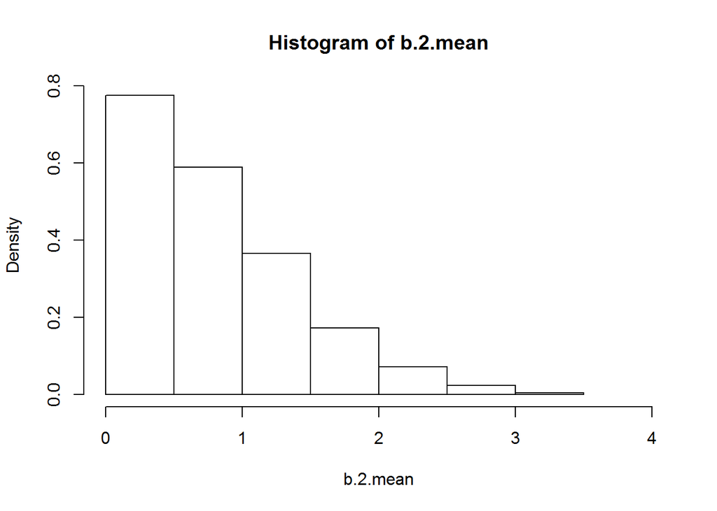

```r
#LLN
hist(b.2.mean, prob=T,xlim=(c(0,4)))
```

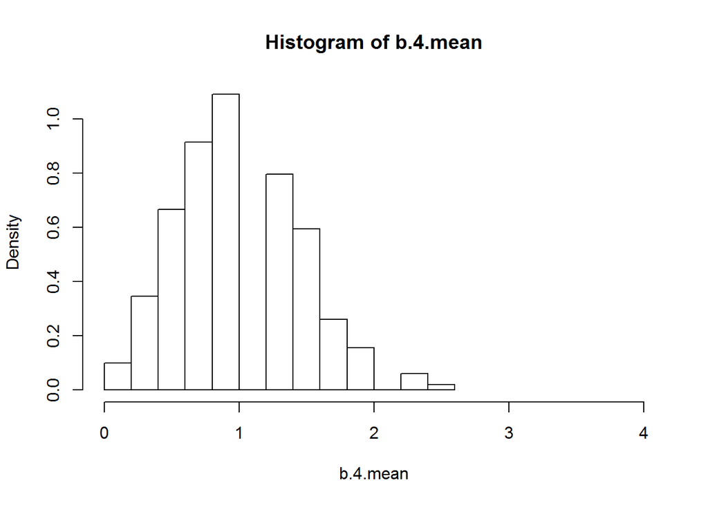

```r
hist(b.4.mean, prob=T,xlim=(c(0,4)))
```

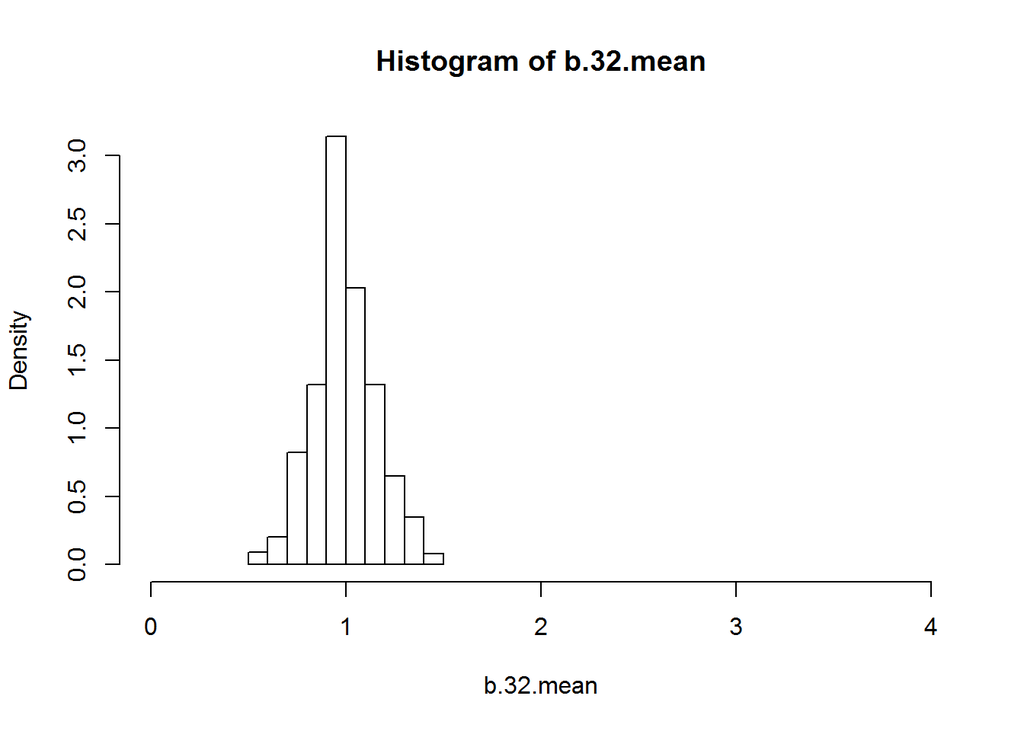

```r
hist(b.32.mean, prob=T,xlim=(c(0,4)))
```

- 중심극한정리(Central Limit Theorem) : i.i.d 표본 표본평균의 확률분포는 표본의 수가 많으면 정규분포로 수렴한다. (모집단과 관계 없음)

$$X_i\sim N(\mu,\sigma) \rightarrow \bar{X}\sim N(\mu,\sigma/
\sqrt{N})\quad\mbox {정규분포의 특성}$$

$$X_i\sim (\mu,\sigma) \rightarrow \bar{X}\sim N(\mu,\sigma/
\sqrt{N})\quad \mbox {모든분포}$$

$$X_i\sim (\mu,\sigma) \rightarrow \sqrt{N}(\bar{X}-\mu)/\sigma \sim N(0,1)\quad \mbox {모든분포}$$

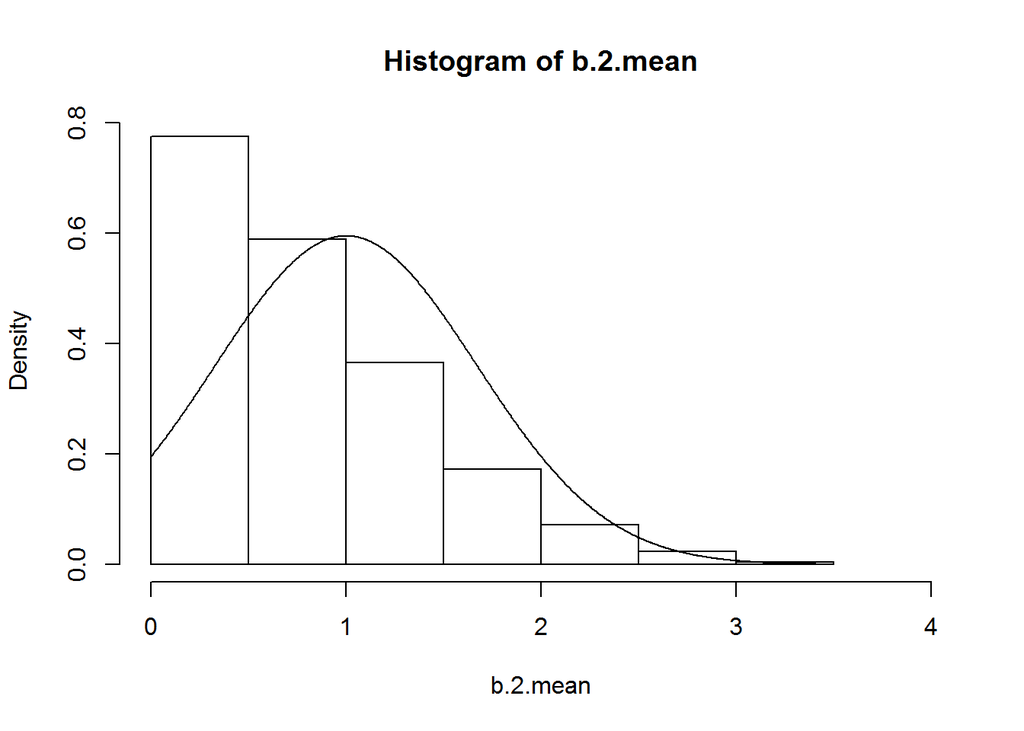

```r
#CLT
hist(b.2.mean, prob=T,xlim=(c(0,4)))
x1=seq(min(b.2.mean),max(b.2.mean),length=1000)
y1=dnorm(x=x1,mean=1,sd=sqrt(t*p*(1-p))/sqrt(2))
lines(x1,y1)
```

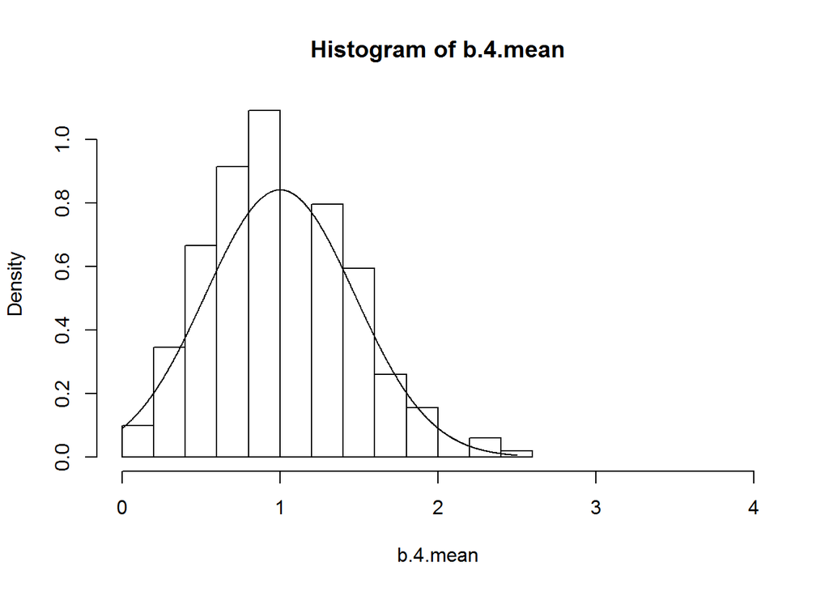

```r
hist(b.4.mean, prob=T,xlim=(c(0,4)))
x2=seq(min(b.4.mean),max(b.4.mean),length=1000)
y2=dnorm(x=x2,mean=1,sd=sqrt(t*p*(1-p))/sqrt(4))
lines(x2,y2)
```

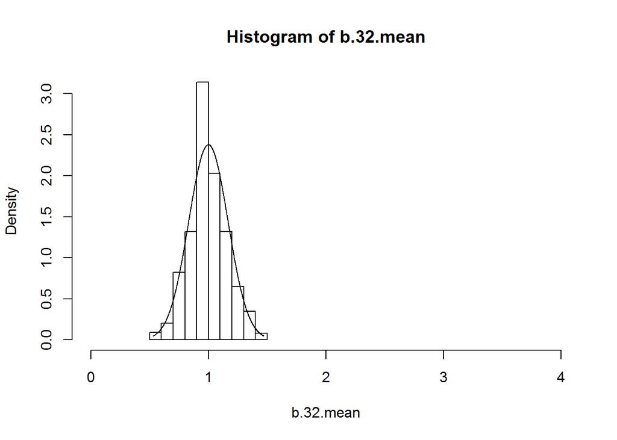

```r
hist(b.32.mean, prob=T,xlim=(c(0,4)))
x3=seq(min(b.32.mean),max(b.32.mean),length=1000)
y3=dnorm(x=x3,mean=1,sd=sqrt(t*p*(1-p))/sqrt(32))
lines(x3,y3)
```

#### B. 다양한 (표본)분포

1.$\chi^2$ 분포

$$X=\sum_i Z^2_i\qquad Z_i\sim N(0,1) \qquad i.i.d$$

모수: 자유도 $k$

$${Z_i}^2\sim \chi^2(1)\qquad X\sim \chi^2(k)$$
$$E(X) = k\qquad V(X)=2k$$

표본분산 $S^2=\sum_i(X_i-\bar{X})^2/(n-1)\qquad X_i\sim N(\mu,\sigma)$

$$(n-1)S^2/\sigma^2\sim\chi^2(n-1)$$
$$E(S^2)=\frac{\sigma^2}{n-1}E((n-1)S^2/\sigma^2)=\frac{\sigma^2}{n-1}\times (n-1)=\sigma^2$$
$$V(S^2)=V[\frac{\sigma^2}{n-1}(n-1)S^2/\sigma^2]=\frac{(\sigma^2)^2}{(n-1)^2}\times V((n-1)S^2/\sigma^2)\\
=\frac{(\sigma^2)^2}{(n-1)^2}\times 2(n-1)=\frac{2\sigma^4}{n-1}$$

교과서 p.170 그림 4-10.

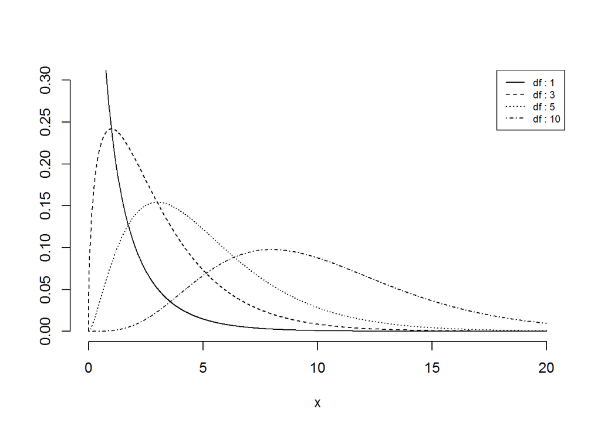

```r
df <- c(1, 3, 5, 10)
x <- seq(0, 20, by=0.01)
chi2.1 <- dchisq(x, df[1])
chi2.3 <- dchisq(x, df[2])
chi2.5 <- dchisq(x, df[3])
chi2.10 <- dchisq(x, df[4])
plot(x, type="n", xlim=c(0, 20), ylim=c(0, 0.3), main="", xlab="x", ylab="", axes=F)

axis(1)
axis(2)
lines(x, chi2.1, lty=1)
lines(x, chi2.3, lty=2)
lines(x, chi2.5, lty=3)
lines(x, chi2.10, lty=4)
legend("topright", paste("df :", df), lty=1:4, cex=0.7)
```

2. t 분포
- $Z\sim N(0,1), V\sim \chi^2(k)$ Z, V 상호 독립

$$T =\frac{Z}{\sqrt{V/k}}\sim t(k)$$

- $\bar{X}\sim N(\mu,\sigma^2/N),(N-1)S^2/\sigma^2\sim \chi^2(N-1)\qquad$, $\bar{X}, (N-1)S^2/\sigma^2$ 상호독립

$$T =\frac{(\bar{X}-\mu)/(\sigma/\sqrt{N})}{\sqrt{(N-1)S^2/\sigma^2(N-1)}}=\frac{\bar{X}-\mu}{S/\sqrt{N}}\sim t(N-1)$$
교과서 p.172 그림 4-11

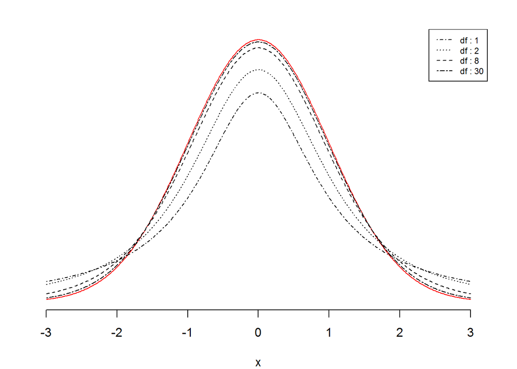

```r
df <- c(1, 2, 8, 30)
x <- seq(-3, 3, by=0.01)
y <- dnorm(x)
t.1 <- dt(x, df=df[1])
t.2 <- dt(x, df=df[2])
t.8 <- dt(x, df=df[3])
t.30 <- dt(x, df=df[4])

par(mar=c(4,2,2,2))
plot(x, y, type="l", lty=1, axes=F, xlab="x", ylab="", col="red")
axis(1)
lines(x, t.1, lty=4)
lines(x, t.2, lty=3)
lines(x, t.8, lty=2)
lines(x, t.30, lty=6)
legend("topright", paste("df :", df), lty=c(4, 3, 2, 6), cex=0.7)
```

- 평균과 분산
  - 자유도가 1인 t 분포는 Caushy 분포라는 다른 이름이 있는데, 이 분포의 평균과 분산은 정할 수 없다.(undetermiend)
  - 자유도가 2 이상인 t 분포의 평균과 분산은 다음과 같다.
    $$T =\frac{Z}{\sqrt{V/k}}\sim t(k) \qquad (k\ge 2)$$
    $$E(T)=0$$
    $$V(T)=\frac{k}{k-2}$$
3. F 분포.
- $V_1\sim \chi^2(k_1), V_2\sim \chi^2(k_2)$ V1 V2 상호 독립

$$F=\frac{V_1/k_1}{V_2/k_2}\sim F(k_1,k_2)$$

- 평균과 분산

$$F\sim F(m,n)
\\E(F) =\frac{m}{m-2} \quad (m\ge 3)\\
V(F)=\frac{2m^2(n+m-2)}{n(m-2)^2(m-4)} \quad (m>5)$$

- 분산의 비율과 F 분포

$$X_i\sim N(0,\sigma^2_1),\quad i=1...n \\ Y_j\sim N(0,\sigma^2_2)\quad j=1...m\\{X_i,Y_j} \quad\mbox{independent}$$
$$S^2_1=\frac{\sum_i^m(X_i-\bar{X})^2}{n-1},\quad (n-1)S^2_1/\sigma^2_1\sim \chi^2(n-1)
\\S^2_2=\frac{\sum_j^m(Y_j-\bar{Y})^2}{m-1}\quad (m-1)S^2_2/\sigma^2_2\sim \chi^2(m-1)$$

$$F=\frac{(n-1) S^2_1/\sigma^2_1(n-1)}{(m-1) S^2_2/\sigma^2_2(m-1)}
=\frac{S^2_1/\sigma^2_1}{S^2_2/\sigma^2_2}=\frac{S^2_1}{S^2_2}\times \frac{\sigma^2_2}{\sigma^2_1}\sim F(n-1,m-1)$$

그래서?

$$E(\frac{S^2_1}{S^2_2}\times \frac{\sigma^2_2}{\sigma^2_1})=\frac{n-1}{n-3}\\
\frac{\sigma^2_2}{\sigma^2_1}\sim \frac{S^2_2}{S^2_1}\frac{n-1}{n-3}$$

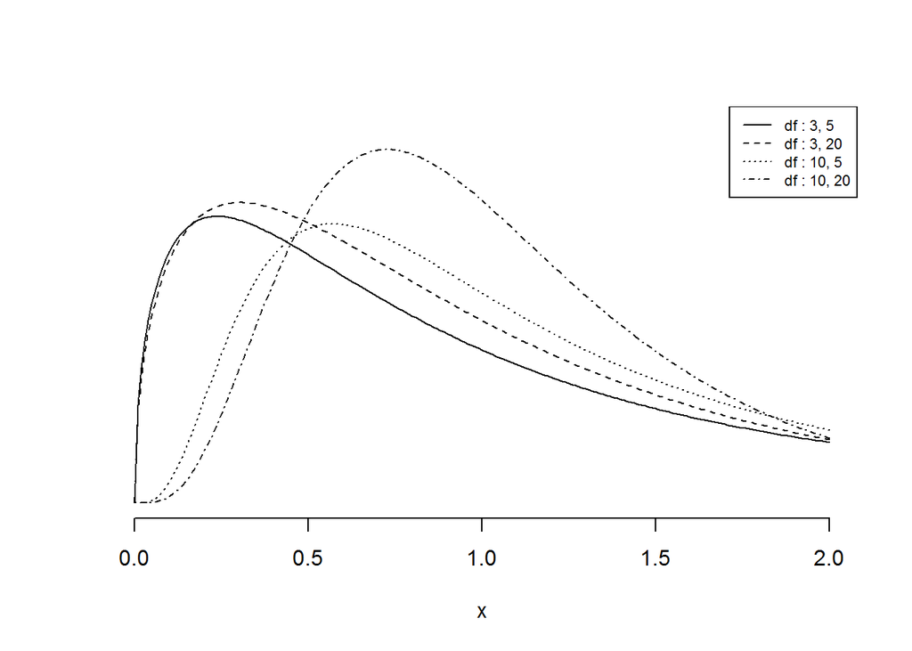

```r
df1 <- c(3, 10)
df2 <- c(5, 20)
x <- seq(0, 2, by=0.01)

f3.5 <- df(x, df1[1], df2[1])
f3.20 <- df(x, df1[1], df2[2])
f10.5 <- df(x, df1[2], df2[1])
f10.20 <- df(x, df1[2], df2[2])

plot(x, f3.5, type="l", ylim=c(0, 0.9), axes=F, xlab="x", ylab="")
axis(1)
lines(x, f3.20, lty=2)
lines(x, f10.5, lty=3)
lines(x, f10.20, lty=4)

legend("topright", paste("df :", c("3, 5", "3, 20", "10, 5", "10, 20")), lty=1:4, cex=0.7)
```

- F test.

$$X_i\sim N(\mu_1,\sigma^2),\quad i=1...n \\ Y_j\sim N(0,\sigma^2)\quad j=1...m\\{X_i,Y_j} \quad\mbox{independent}$$
(평균이 0 이 아닌 경우)

$$S^2_1=\frac{\sum_i^m(X_i-\bar{X})^2}{n-1},\quad (n-1)S^2_1/\sigma^2\sim \chi^2(n-1,\mu^2)\qquad{\mbox{noncentral chi}}
\\S^2_2=\frac{\sum_j^m(Y_j-\bar{Y})^2}{m-1}\quad (m-1)S^2_2/\sigma^2\sim \chi^2(m-1)$$

$$\mbox {non central F 분포}
\\ F=\frac{(n-1) S^2_1/\sigma^2(n-1)}{(m-1) S^2_2/\sigma^2(m-1)}
=\frac{S^2_1/\sigma^2}{S^2_2/\sigma^2}=\frac{S^2_1}{S^2_2}\sim F(n-1,m-1,\lambda)$$

[figure not shown]

```r
df1 =3
df2 =5
x <- seq(0, 10, by=0.01)

f3.5 <- df(x, df1, df2)
f3.20 <- df(x, df1, df2,5)
f10.5 <- df(x, df1, df2,10)
f10.20 <- df(x, df1, df2,50)

plot(x, f3.5, type="l", ylim=c(0, 0.9), axes=F, xlab="x", ylab="")
axis(1)
lines(x, f3.20, lty=2)
lines(x, f10.5, lty=3)
lines(x, f10.20, lty=4)

legend("topright", paste("lambda :", c("0", "1", "10", "20")), lty=1:4, cex=0.7)
```

- F test 회귀분석

$$\mbox{Model 1: }\quad y = [X,1]\beta +\epsilon, \quad X_[n\times (k-1)],\quad \epsilon \sim N(0,\sigma^2)$$
$$\hat{\beta}=(X'X)^{-1}X'y,\quad E(\hat{\beta})=\beta\\
\hat{y}=X\hat{\beta}$$

$$\mbox{Model 2: }\quad y = [1]\beta_1 +\epsilon_1, \quad \epsilon \sim N(0,\sigma^2)$$
$$\hat{\beta}_1=(1'1)^{-1}1'y=\bar{y}\quad E(\hat{\beta}_1)=\beta_1\\
\hat{y}_1=[1]\hat{\beta}_1=[1]\bar{y}$$

회귀분석 F test 검정통계량

$$F=\frac{\sum_i (\hat{y}_i-\hat{y}_1)/(k-1)}{\sum_i (y_i-\hat{y}_1)/(n-1)}$$

만약 $\{\beta_2,\beta_3,...\beta_k\} =\{0,0,...,0\}, i.e. \beta=\beta_1$

$$\hat{\beta}\sim\hat{\beta}_1 \rightarrow \hat{y}\sim \hat{y}_1 \\
E(\hat{y}-\hat{y}_1)=E(\hat{y}-[1]\bar{y})=XE(\hat{\beta})-XE(\hat{\beta}_1)=X(\beta-\beta_1)=0\\
F\sim F(k-1,n-1,0)$$

만약 $\{\beta_2,\beta_3,...\beta_k\} \neq\{0,0,...,0\} i.e. \beta\neq\beta_1$

$$\hat{\beta}<>\hat{\beta}_1 \rightarrow \hat{y}<> \hat{y}_1 \\
E(\hat{y}-\hat{y}_1)=E(\hat{y}-[1]\bar{y})\neq 0\\
F\sim F(k-1,n-1,\lambda),\qquad \lambda\neq 0\quad \mbox{non central F}$$
그래서 central F 분포일 경우보다는 큰 값이 나올 확률이 높아진다. 실제로 높은 값의 F 통계치가 나오면 $\{\beta_2,\beta_3,...\beta_k\} = \{0,0,...,0\}$ 일 가정을 폐기한다.

#### C. 다음단원 준비(R function)

```r
options(digits=4)
var.p2 <- function(x, na.rm=FALSE) {
  if(na.rm == TRUE){
    x <- x[!is.na(x)]
  }
  n <- length(x)
  m <- mean(x, na.rm=na.rm)
  num <- sum( (x - m)^2, na.rm=na.rm )
  denom <- n
  var <- num / denom
  return( var )
}

radius <- c(234, 234, 234, 233, 233, 233, NA, 231, 232, 231)
weight=c(146.3,146.4,144.1,146.7,145.2,144.1,143.3, 147.3,146.7,147.3)

var.p2(radius)
```

```
## [1] NA
```

```r
var.p2(radius, na.rm=TRUE)
```

```
## [1] 1.284
```

```r
var.p2(weight)
```

```
## [1] 1.908
```